# Taipei accident analysis

2019/7/25

#### 108夏季學院DSP第6組-台北交通

組員: [黃科銓](https://kevinhuang102888.github.io/kevinhuang/week3/final%20project/taipei_accident) [楊岳錩](https://wilson1304983.github.io/666666/week3/final.html) [胡煜欣](https://cinnyhu.github.io/Class/Week3/wwww.html)

## 概論

我們在**臺北市資料大平台**裡，找到一份有趣的資料——「交通事故資訊」，於是想從這份資料，探究*什麼樣的人比較容易發生交通事故(who)*、*什麼的時段比較容易發生交通事故(when)*以及*什麼區域最容易發生交通事故(where)*等三個問題，目前這頁網站主要討論第二個問題，想以「時段」的角度看臺北市交通事故的問題，整理出每日各時的事故易發點，以協助安全出行。

## 資料介紹

此資料來自**臺北市資料大平台**，以「107年-臺北市A1及A2類交通事故明細.csv」此資料為主要分析，裡面的column有「發生年、發生月、發生日、發生時 發生分、處理別、區序、肇事地點、死亡人數、受傷人數、當事人序、車種、性別、年齡、受傷程度、天候、速限、道路型態以及事故位置」，而總資料數有50330筆。

[臺北市交通事故](https://data.taipei/#/dataset/detail?id=2f238b4f-1b27-4085-93e9-d684ef0e2735)

## Code

1.解壓,讀數據

```r
#解壓
library(dplyr)
library(tidyverse)
#將一些數據值設為int
a <- read_csv("107jiaotong.csv",col_types = cols(
  發生年 = col_integer(),
  發生月 = col_integer(),
  發生日 = col_integer(),
  發生時 = col_integer(),
  發生分 = col_integer(),
  處理別 = col_integer(),
  區序 = col_character(),
  肇事地點 = col_character(),
  死亡人數 = col_integer(),
  受傷人數 = col_integer(),
  當事人序 = col_integer(),
  車種 = col_character(),
  性別 = col_integer(),
  年齡 = col_integer(),
  受傷程度 = col_integer(),
  `4天候` = col_integer(),
  `7速限` = col_integer(),
  `8道路型態` = col_integer(),
  `9事故位置` = col_integer()
), locale = locale(encoding = "BIG5"))
#命名道路型態
l<-c("有遮斷器","無遮斷器","三岔路","四岔路","多岔路","隧道","地下道","橋樑","涵洞","高架道路","彎曲路及附近","坡路","巷弄","直路","其他","圓環","廣場")
```

2.整理 * 按時間篩,循環道路型態

```r
#取數據
v=vector(mode="integer",length=17)
b<-filter(a,發生時==0)
for(j in 1:17)
{
  d = filter(b, `8道路型態` == j)
  v[j]<-count(d)
}
s0 <- tibble(case=l,"0時"=as.integer(v[1:17]))

b<-filter(a,發生時==1)
for(j in 1:17)
{
  d = filter(b, `8道路型態` == j)
  v[j]<-count(d)
}
s1 <- tibble(case=l,"1時"=as.integer(v[1:17]))

b<-filter(a,發生時==2)
for(j in 1:17)
{
  d = filter(b, `8道路型態` == j)
  v[j]<-count(d)
}
s2 <- tibble(case=l,"2時"=as.integer(v[1:17]))

b<-filter(a,發生時==3)
for(j in 1:17)
{
  d = filter(b, `8道路型態` == j)
  v[j]<-count(d)
}
s3 <- tibble(case=l,"3時"=as.integer(v[1:17]))

b<-filter(a,發生時==4)
for(j in 1:17)
{
  d = filter(b, `8道路型態` == j)
  v[j]<-count(d)
}
s4 <- tibble(case=l,"4時"=as.integer(v[1:17]))

b<-filter(a,發生時==5)
for(j in 1:17)
{
  d = filter(b, `8道路型態` == j)
  v[j]<-count(d)
}
s5 <- tibble(case=l,"5時"=as.integer(v[1:17]))

b<-filter(a,發生時==6)
for(j in 1:17)
{
  d = filter(b, `8道路型態` == j)
  v[j]<-count(d)
}
s6 <- tibble(case=l,"6時"=as.integer(v[1:17]))

b<-filter(a,發生時==7)
for(j in 1:17)
{
  d = filter(b, `8道路型態` == j)
  v[j]<-count(d)
}
s7 <- tibble(case=l,"7時"=as.integer(v[1:17]))

b<-filter(a,發生時==8)
for(j in 1:17)
{
  d = filter(b, `8道路型態` == j)
  v[j]<-count(d)
}
s8 <- tibble(case=l,"8時"=as.integer(v[1:17]))

b<-filter(a,發生時==9)
for(j in 1:17)
{
  d = filter(b, `8道路型態` == j)
  v[j]<-count(d)
}
s9 <- tibble(case=l,"9時"=as.integer(v[1:17]))

b<-filter(a,發生時==10)
for(j in 1:17)
{
  d = filter(b, `8道路型態` == j)
  v[j]<-count(d)
}
s10 <- tibble(case=l,"10時"=as.integer(v[1:17]))

b<-filter(a,發生時==11)
for(j in 1:17)
{
  d = filter(b, `8道路型態` == j)
  v[j]<-count(d)
}
s11 <- tibble(case=l,"11時"=as.integer(v[1:17]))

b<-filter(a,發生時==12)
for(j in 1:17)
{
  d = filter(b, `8道路型態` == j)
  v[j]<-count(d)
}
s12 <- tibble(case=l,"12時"=as.integer(v[1:17]))

b<-filter(a,發生時==13)
for(j in 1:17)
{
  d = filter(b, `8道路型態` == j)
  v[j]<-count(d)
}
s13 <- tibble(case=l,"13時"=as.integer(v[1:17]))

b<-filter(a,發生時==14)
for(j in 1:17)
{
  d = filter(b, `8道路型態` == j)
  v[j]<-count(d)
}
s14 <- tibble(case=l,"14時"=as.integer(v[1:17]))

b<-filter(a,發生時==15)
for(j in 1:17)
{
  d = filter(b, `8道路型態` == j)
  v[j]<-count(d)
}
s15 <- tibble(case=l,"15時"=as.integer(v[1:17]))

b<-filter(a,發生時==16)
for(j in 1:17)
{
  d = filter(b, `8道路型態` == j)
  v[j]<-count(d)
}
s16 <- tibble(case=l,"16時"=as.integer(v[1:17]))

b<-filter(a,發生時==17)
for(j in 1:17)
{
  d = filter(b, `8道路型態` == j)
  v[j]<-count(d)
}
s17 <- tibble(case=l,"17時"=as.integer(v[1:17]))

b<-filter(a,發生時==18)
for(j in 1:17)
{
  d = filter(b, `8道路型態` == j)
  v[j]<-count(d)
}
s18 <- tibble(case=l,"18時"=as.integer(v[1:17]))

b<-filter(a,發生時==19)
for(j in 1:17)
{
  d = filter(b, `8道路型態` == j)
  v[j]<-count(d)
}
s19 <- tibble(case=l,"19時"=as.integer(v[1:17]))

b<-filter(a,發生時==20)
for(j in 1:17)
{
  d = filter(b, `8道路型態` == j)
  v[j]<-count(d)
}
s20 <- tibble(case=l,"20時"=as.integer(v[1:17]))

b<-filter(a,發生時==21)
for(j in 1:17)
{
  d = filter(b, `8道路型態` == j)
  v[j]<-count(d)
}
s21 <- tibble(case=l,"21時"=as.integer(v[1:17]))

b<-filter(a,發生時==22)
for(j in 1:17)
{
  d = filter(b, `8道路型態` == j)
  v[j]<-count(d)
}
s22 <- tibble(case=l,"22時"=as.integer(v[1:17]))

b<-filter(a,發生時==23)
for(j in 1:17)
{
  d = filter(b, `8道路型態` == j)
  v[j]<-count(d)
}
s23 <- tibble(case=l,"23時"=as.integer(v[1:17]))
#合併
t0<-merge(s0, s1, by = "case")
t0<-merge(t0, s2, by = "case")
t0<-merge(t0, s3, by = "case")
t0<-merge(t0, s4, by = "case")
t0<-merge(t0, s5, by = "case")
t0<-merge(t0, s6, by = "case")
t0<-merge(t0, s7, by = "case")
t0<-merge(t0, s8, by = "case")
t0<-merge(t0, s9, by = "case")
t0<-merge(t0, s10, by = "case")
t0<-merge(t0, s11, by = "case")
t0<-merge(t0, s12, by = "case")
t0<-merge(t0, s13, by = "case")
t0<-merge(t0, s14, by = "case")
t0<-merge(t0, s15, by = "case")
t0<-merge(t0, s16, by = "case")
t0<-merge(t0, s17, by = "case")
t0<-merge(t0, s18, by = "case")
t0<-merge(t0, s19, by = "case")
t0<-merge(t0, s20, by = "case")
t0<-merge(t0, s21, by = "case")
t0<-merge(t0, s22, by = "case")
t0<-merge(t0, s23, by = "case")
#方便繪圖
tt0<-gather(t0,`0時`,`1時`,`2時`,`3時`,`4時`,`5時`,`6時`,`7時`,`8時`,`9時`,`10時`,`11時`,`12時`,`13時`,`14時`,`15時`,`16時`,`17時`,`18時`,`19時`,`20時`,`21時`,`22時`,`23時`
  , key = "time", value = "cases")
#順序
tt0$time2 <- factor(tt0$time,levels=unique(tt0$time))
```

3.畫圖

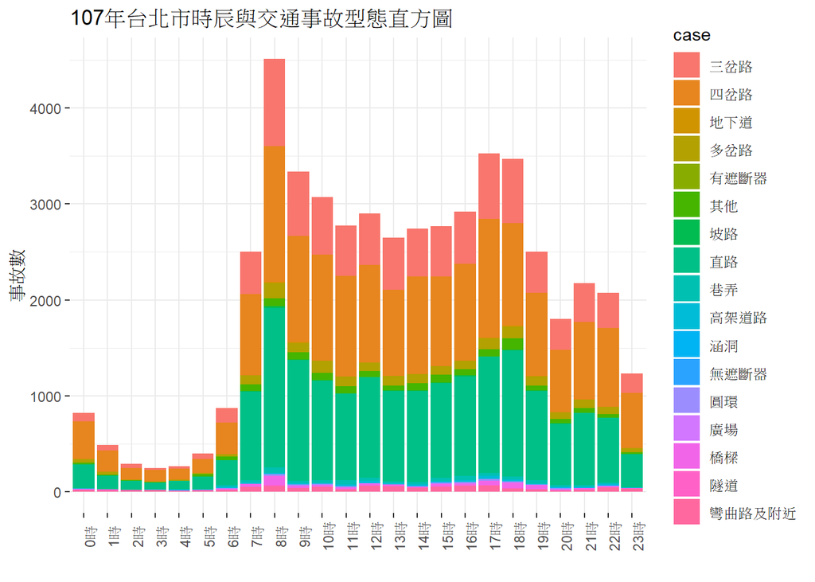

```r
#堆疊直方圖
ggplot(data=tt0,aes(x=time2,y=cases,fill=case))+geom_bar(stat="identity")+labs(title = "107年台北市時辰與交通事故型態直方圖",x='',y="事故數")+theme_bw()+theme(panel.border = element_blank())+ theme(axis.text.x = element_text(angle = 90))
```

### [後](https://cinnyhu.github.io/Class/Week3/www.html)